# 🌍 Analyzing World Freedom Data

#### By: Mantas Siukstas

#### Date: 2023-09-06

### About the Data

**Source:** [The Human Freedom Index 2022](https://www.kaggle.com/datasets/gsutters/the-human-freedom-index?select=hfi_cc_2022.csv)

**Citation:** Ian Vásquez, Fred McMahon, Ryan Murphy, and Guillermina Sutter Schneider, The Human Freedom Index 2022: A Global Measurement of Personal, Civil, and Economic Freedom (Washington: Cato Institute and the Fraser Institute, 2022).

**License:** Open Database

### Project Overview:

In this analysis, we'll dive deep into understanding global freedom patterns. Here are the main questions we're looking to answer:

- Which countries rank highest in terms of freedom?
- How does economic freedom correlate with human freedom?
- Can a country's geographical context influence its freedom scores?

To get started, I import the necessary libraries and load the data. Let's take a peek at how it looks.

```python
# Importing libraries:

import pandas as pd # pandas for data manipulation and analysis
import numpy as np # numpy for numerical operations
import seaborn as sns # seaborn for statistical data visualization
import matplotlib.pyplot as plt # matplotlib for plotting and visualization
from matplotlib.colors import LinearSegmentedColormap #extra colors for data viz
```

```python
# Reading the CSV file into a pandas DataFrame
data_2022 = pd.read_csv('hfi_cc_2022.csv')

# Displaying the first 5 rows of the DataFrame
data_2022.head()
```

|  | year | countries | region | hf_score | hf_rank | hf_quartile | pf_rol_procedural | pf_rol_civil | pf_rol_criminal | pf_rol_vdem | ... | ef_regulation_business_adm | ef_regulation_business_burden | ef_regulation_business_start | ef_regulation_business_impartial | ef_regulation_business_licensing | ef_regulation_business_compliance | ef_regulation_business | ef_regulation | ef_score | ef_rank |
| --- | --- | --- | --- | --- | --- | --- | --- | --- | --- | --- | --- | --- | --- | --- | --- | --- | --- | --- | --- | --- | --- |
| 0 | 2020 | Albania | Eastern Europe | 7.67 | 47.0 | 2.0 | 5.903741 | 4.725831 | 4.047825 | 7.194198 | ... | 5.651538 | 6.000000 | 9.742477 | 5.9975 | 5.621940 | 7.175250 | 6.698118 | 7.112958 | 7.64 | 26.0 |
| 1 | 2020 | Algeria | Middle East & North Africa | 5.13 | 154.0 | 4.0 | 4.913311 | 5.503872 | 4.254187 | 5.461189 | ... | 4.215154 | 2.222222 | 9.305002 | 2.5775 | 8.771111 | 7.029528 | 5.686753 | 5.778953 | 5.12 | 157.0 |
| 2 | 2020 | Angola | Sub-Saharan Africa | 5.97 | 122.0 | 3.0 | 2.773262 | 4.352009 | 3.478950 | 5.306695 | ... | 2.937894 | 3.111111 | 8.730805 | 4.7025 | 7.916416 | 6.782923 | 5.696942 | 6.227545 | 5.91 | 138.0 |
| 3 | 2020 | Argentina | Latin America & the Caribbean | 6.99 | 74.0 | 2.0 | 6.824288 | 5.679943 | 4.218635 | 6.748978 | ... | 2.714233 | 5.555556 | 9.579288 | 7.2675 | 5.726521 | 6.508295 | 6.225232 | 5.490538 | 4.87 | 161.0 |
| 4 | 2020 | Armenia | Caucasus & Central Asia | 8.14 | 26.0 | 1.0 | NaN | NaN | NaN | 7.204175 | ... | 5.170406 | 5.111111 | 9.863530 | 6.2600 | 9.302574 | 7.040738 | 7.124727 | 7.756333 | 7.84 | 11.0 |

5 rows × 141 columns

### **Dataset Overview**:

We've loaded a dataset detailing countries and their respective freedom scores. Let's dive into its structure, columns, and the range of years it covers. Immediatelty could see that even the dataset is from 2022 the newest values are from the year 2020. To keep the values fresh the analysis will be using the values from year 2020.

### **Data Cleaning**:

Datasets often come with missing values or duplicates. It's crucial to identify and decide how they are going to be managed. This step ensures our analyses are as accurate as possible.

### **Filtering for Quality**:

For this analysis, we're focusing on the top countries. Many lower-ranked countries have substantial missing data, making them less reliable for our purposes. By narrowing our focus, we ensure a more robust sample for data analysis focusing on best performers in this dataset.

Time to dive into the code and see what the data tells us.

**Note: Hong Kong was selected as the country for interesting data insights.*

```python
# Column names of the data_2022 DataFrame
print(data_2022.columns)
```

```
Index(['year', 'countries', 'region', 'hf_score', 'hf_rank', 'hf_quartile',
       'pf_rol_procedural', 'pf_rol_civil', 'pf_rol_criminal', 'pf_rol_vdem',
       ...
       'ef_regulation_business_adm', 'ef_regulation_business_burden',
       'ef_regulation_business_start', 'ef_regulation_business_impartial',
       'ef_regulation_business_licensing', 'ef_regulation_business_compliance',
       'ef_regulation_business', 'ef_regulation', 'ef_score', 'ef_rank'],
      dtype='object', length=141)
```

```python
# Finding the earliest and the latest year in the 'year' column
min_year = data_2022['year'].min()
max_year = data_2022['year'].max()

# Printing the range of years in the dataset
print(f"The dataset ranges from {min_year} to {max_year}.")
```

```
The dataset ranges from 2000 to 2020.
```

```python
# Calculating the number of missing values for each column
missing_values = data_2022.isnull().sum()

# Printing the missing values count per column
print(missing_values)
```

```
year                                   0
countries                              0
region                                 0
hf_score                             382
hf_rank                              382
                                    ...
ef_regulation_business_compliance    422
ef_regulation_business               417
ef_regulation                        350
ef_score                             382
ef_rank                              382
Length: 141, dtype: int64
```

```python
# Displaying the data types of each column in the dataset
print(data_2022.dtypes)

# Counting the number of each data type in the dataset
dtype_counts = data_2022.dtypes.value_counts()
print(dtype_counts)
```

```
year                                   int64
countries                             object
region                                object
hf_score                             float64
hf_rank                              float64
                                      ...
ef_regulation_business_compliance    float64
ef_regulation_business               float64
ef_regulation                        float64
ef_score                             float64
ef_rank                              float64
Length: 141, dtype: object
float64    133
object       5
int64        3
Name: count, dtype: int64
```

```python
# Read the dataset for the year 2020
data_2020 = data_2022[data_2022['year'] == 2020]

# Select specific columns from the 2020 data
data_filtered = data_2020[['countries', 'region', 'ef_score', 'ef_rank', 'hf_score', 'hf_rank']]

# Remove rows with null values in 'countries' column
data_filtered = data_filtered.dropna(subset=['countries'])

# Remove duplicate rows in 'countries' column
data_cleaned = data_filtered.drop_duplicates(subset='countries', keep='first')

# Remove warning messages for cleaner look
import warnings
warnings.filterwarnings('ignore')
```

```python
# Renaming countries in the 'countries' column
country_renames = {
    'Kyrgyz Republic': 'Kyrgyzstan',
    'Brunei Darussalam': 'Brunei',
    'United Arab Emirates': 'UAE',
    'Gambia, The': 'Gambia',
    'Russian Federation': 'Russia',
    'Hong Kong SAR, China': 'Hong Kong',
    'Korea, Rep.': 'South Korea',
    'Papua New Guinea': 'New Guinea'
}

data_cleaned['countries'] = data_cleaned['countries'].replace(country_renames)
```

```python
# Get the number of unique countries left in the cleaned dataset
num_countries = data_cleaned.shape[0]
print(num_countries)
```

```
165
```

## Data Visualizations: Exploring a Freedom Scores

In our data-driven world, the quest for understanding **freedom** can be navigated through numbers. The further analysis delves into understanding how countries fare in terms of human and economic freedoms. We will address questions like:

- Is there a correlation between human and economic freedom scores?
- Which countries top the charts in both kinds of freedom?
- Are there regional powerhouses that stand out?

### Statistical Footprints:

Throughout our visualization journey:

- **Correlation** serves as our compass. It's a statistical measure allowing us to gauge the strength and direction of a linear relationship between two quantitative variables.
- **Ranking** makes its presence known. By focusing on relative positions, we move away from the absolute magnitude of freedom scores to a hierarchy of nations.
- **region-based breakdown** - reminiscent of stratification in statistics, a method that splits a dataset into homogeneous subgroups.
- **Edward Tufte’s principles** is data-to-ink ratio, generally stating that when creating a visualization, you should try to maximize the amount of "ink" (physical or digital) used to represent the data, and minimize the amount used to represent everything else not important to understanding.

Furthermore, Python libraries such as Seaborn and Matplotlib allow us to combine data and visualizations. From scatter plots to bar charts, they can provide a clearer understanding of freedom statistics and rankings across the globe.

## 📈 Analyzing the Correlation Between Human and Economic Freedom

The scatter plot visualizes the relationship between Human Freedom Score and Economic Freedom Score for countries across different regions. A few observations:

- **Strong Upward Trend**: The plotted trendline shows a clear upward progression, suggesting that as the Human Freedom Score increases, the Economic Freedom Score tends to increase as well. This is a strong indicator of positive correlation between the two freedom scores, implying that they are somewhat interdependent for the countries.
- **Regional Differences**: Different color markers represent various regions, providing insights into how countries from different geographical contexts fare in terms of freedom scores. It might be beneficial to have a better look into individual regions to understand the nuances better.

Given the positive correlation observed, it raises intriguing questions: Do regions with historically higher economic freedom also have higher human freedom? And vice versa? Exploring the data by region in subsequent visualizations might shed more light on these questions.

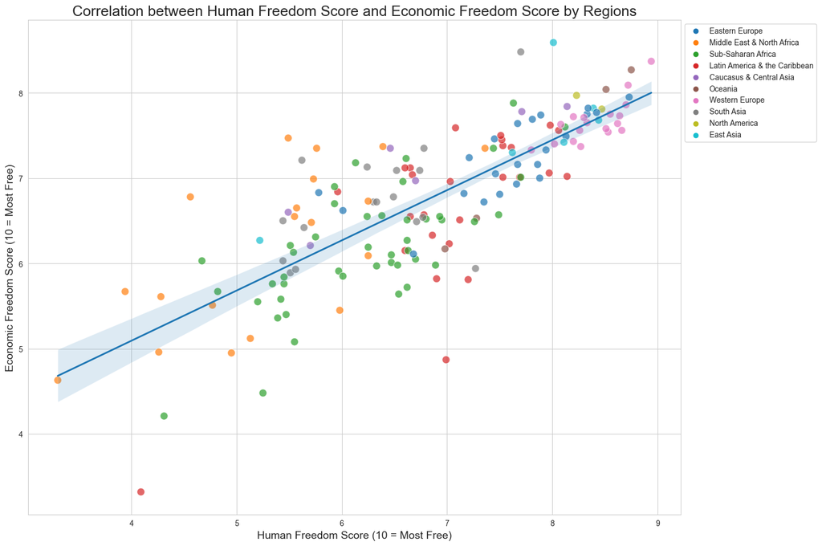

```python
# Setting up the Seaborn style
sns.set_style("whitegrid")

# Plotting the scatter plot with different regions colored differently
plt.figure(figsize=(15,10))
plot = sns.scatterplot(x="hf_score", y="ef_score", hue="region", data=data_cleaned, palette="tab10", s=100, alpha=0.7)

# Plotting a trendline to see the correlation better
sns.regplot(x="hf_score", y="ef_score", data=data_cleaned, scatter=False, ax=plot)

# Styling and labeling
plt.title("Correlation between Human Freedom Score and Economic Freedom Score by Regions", fontsize=19)
plt.xlabel("Human Freedom Score (10 = Most Free)", fontsize=14)
plt.ylabel("Economic Freedom Score (10 = Most Free)", fontsize=14)
plt.legend(loc="upper left", bbox_to_anchor=(1,1))

plt.tight_layout()
plt.show()
```

## Top 20 Countries by Combined Freedom Score

The visualized data provides a panoramic view of the countries that are leading the charts when it comes to a combined measure of human and economic freedom.

- **Switzerland, the Pinnacle**: Topping the list, Switzerland boasts a score of 17.3. Its position reaffirms the country's reputation for being a hub of both human rights and economic opportunity.
- **Close Contenders**: New Zealand and Denmark follow closely with scores of 17.0 and 16.8, respectively. This demonstrates that the top spots are highly competitive, with only marginal differences in scores.
- **Two Values Stand Out**: While countries like Hong Kong and Singapore are high on the list, their distribution between human and economic freedom is distinct. They have slightly lower human freedom scores but outpace many with their economic freedom ratings.
- **The Balancing Act**: Countries like Estonia, Lithuania, and Latvia, despite their relatively small size, display a balanced score, reflecting a commendable balance between human rights and economic policies.
- **Diverse Top 20**: The list showcases a geographically diverse set, spanning continents from North America to Asia and Europe. This suggests that the ethos of freedom isn't confined to a particular region but is a global aspiration.

Considering the close competition among the top contenders, it might be insightful to delve deeper into the regional and historical factors influencing these scores. Additionally, comparing regions can provide more granular insights, revealing patterns and divergences within specific geographies.

***Note: The combined score is a sum of the Human Freedom Score and Economic Freedom Score. A higher score indicates a higher level of freedom.*

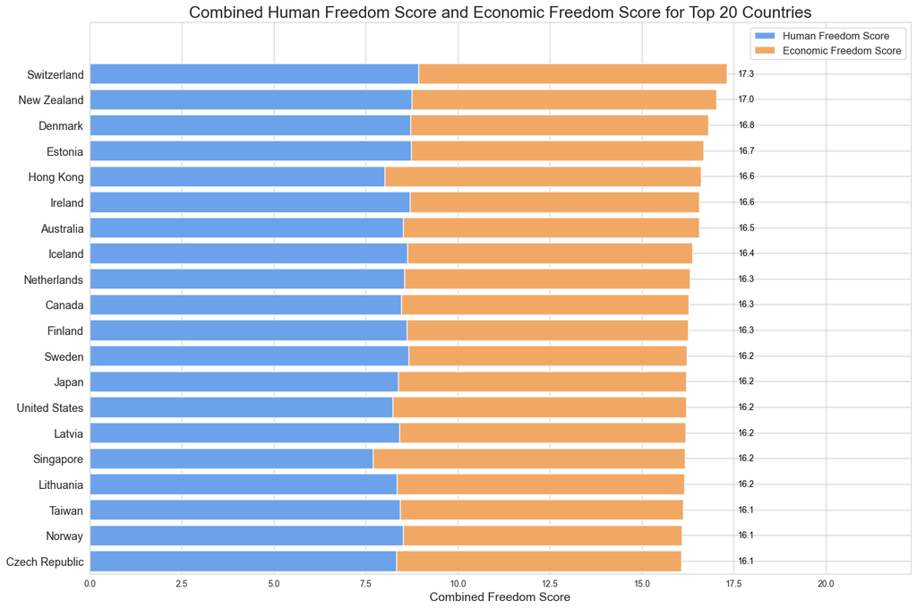

```python
# Creating a 'total_freedom' column
data_cleaned['total_freedom'] = data_cleaned['hf_score'] + data_cleaned['ef_score']

# Get top highest score countries based on the sum of 'hf_score' and 'ef_score'
top20_score = data_cleaned.nlargest(20, 'total_freedom')

# Sorting the data by total freedom scores in descending order
top20_score_sorted = top20_score.sort_values(by='total_freedom', ascending=True)

# Plotting a horizontal stacked bar
plt.figure(figsize=(15, 10))
colors_human = "#6CA2EA" #Blue
colors_economic = "#F2A865" #Orange
bars1 = plt.barh(top20_score_sorted['countries'], top20_score_sorted['hf_score'], label='Human Freedom Score', color=colors_human)
bars2 = plt.barh(top20_score_sorted['countries'], top20_score_sorted['ef_score'], left=top20_score_sorted['hf_score'], label='Economic Freedom Score', color=colors_economic)

# Y/X axes settings
x_max_limit = max(top20_score_sorted['total_freedom']) + 5
plt.xlim(0, x_max_limit)
plt.ylim(-0.5, len(top20_score_sorted['countries']) + 1)

# Displaying the total freedom scores next to the bar
for index, value in enumerate(top20_score_sorted['total_freedom']):
    plt.text(x_max_limit - 4.25, index, str(round(value, 1)), va='center', ha='right', color='black', fontsize=10)

# Styling and labeling
plt.xlabel('Combined Freedom Score', fontsize=14)
plt.title('Combined Human Freedom Score and Economic Freedom Score for Top 20 Countries', fontsize=19)
plt.yticks(fontsize=13)  # Increased fontsize for country names
legend = plt.legend(loc='upper right', fontsize='large', bbox_to_anchor=(1, 1))

plt.tight_layout()
plt.show()
```

## Economic Freedom Rankings

In the realm of global economies, there's a hierarchy where certain nations consistently stays at the top. Let's dissect what the 2020 rankings reveal.

From a data science view, rankings come from analyzing various **features**. It's key to recognize the **feature importance** – which factors weigh more in determining a country's rank. Some countries excel due to fiscal policies, others from trade openness. Understanding feature importance helps highlight what drives a nation's economic freedom. It's also crucial to remember that minor changes in these features can shift rankings significantly.

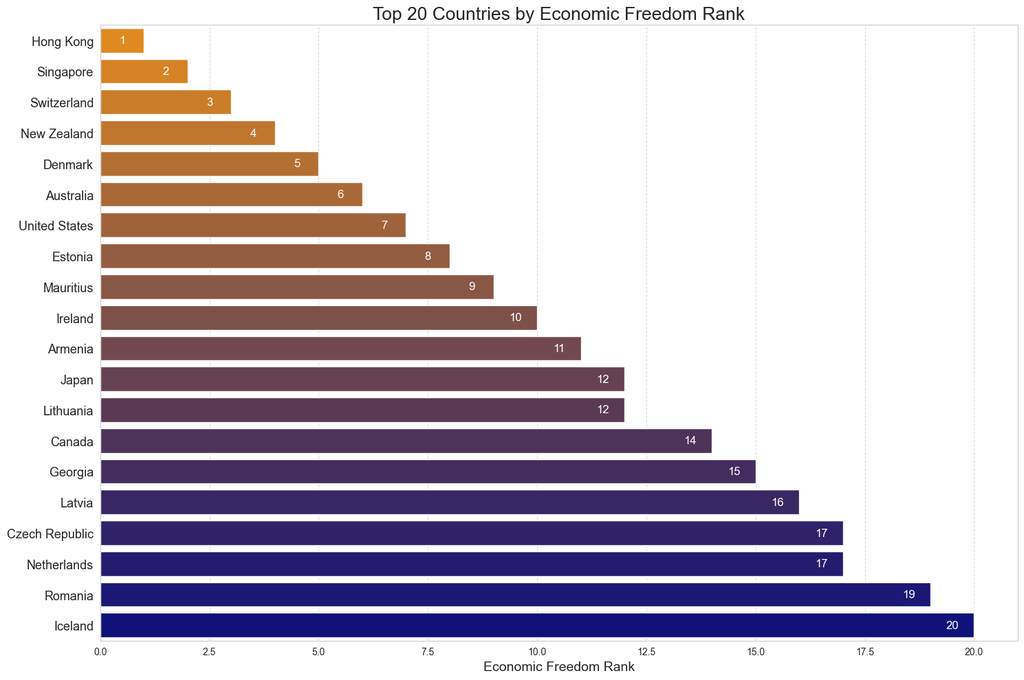

```python
# Get top countries based on 'ef_rank'
top_countries = data_cleaned.nsmallest(20, 'ef_rank')

# Plotting vertical bar chart
plt.figure(figsize=(15, 10))
cmap = sns.color_palette("blend:#FF8C00,#00008B", n_colors=20)
plot = sns.barplot(x='ef_rank', y='countries', data=top_countries, palette=cmap)

# Setting background to white
plot.set_facecolor('white')
plot.grid(axis='x', linestyle='--', alpha=0.7)

# Styling and labeling
plt.title('Top 20 Countries by Economic Freedom Rank', fontsize=19)
plt.xlabel('Economic Freedom Rank', fontsize=14)
plt.ylabel('')  # Removing the 'Country' label
plt.yticks(fontsize=13)  # Increased fontsize for country names

# Display ranks on the bars
for index, value in enumerate(top_countries['ef_rank']):
    plot.text(value - 0.5, index, str(int(value)), va='center', ha='center', color='white', fontsize=12)

plt.tight_layout()
plt.show()
```

## 🌐 **Regional Economic Freedom Leaders**

Analyzing the data, it becomes evident which countries are the pinnacles of economic freedom within their regions:

- **Regional Leaders:** These countries have secured the top ranks in economic freedom within their geographical contexts.
- **Color Significance:** The gradient transition from orange to blue is indicative of rank within the region's top 5; a visual aid to quickly discern positioning.

By examining these regional leaders, we get a nuanced perspective of economic freedom, revealing that global rank isn't the only metric that matters. Regional dominance showcases the influence and benchmark these countries set in their localities.

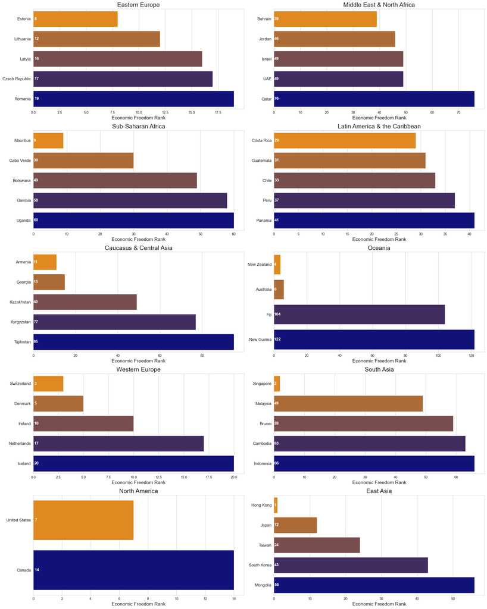

```python
# Setting up the Seaborn style
sns.set_style("whitegrid")

# Create a list of unique regions in the dataset
regions = data_cleaned['region'].unique()

# Custom colormap
cmap = LinearSegmentedColormap.from_list("custom", ["darkorange", "darkblue"], N=5)

# Determine the number of rows needed for the subplots
num_rows = int(np.ceil(len(regions) / 2))

# Setting up the figure and axes
fig, axes = plt.subplots(nrows=num_rows, ncols=2, figsize=(20, 5*num_rows))
fig.tight_layout(pad=5.0)

# Loop through each region and create a bar plot
for region, ax in zip(regions, axes.ravel()):

    # Filter data for the region and get the top 5 countries based on economic freedom ranking
    regional_data = data_cleaned[data_cleaned['region'] == region].sort_values(by='ef_rank').head(5)

    # Colors extracted from the colormap
    colors = [cmap(i) for i in np.linspace(0, 1, len(regional_data))]

    # Create the bar plot
    sns.barplot(x='ef_rank', y='countries', data=regional_data, ax=ax, palette=colors)

    # Styling and labeling
    ax.set_title(region, fontsize=18)
    ax.set_xlabel('Economic Freedom Rank', fontsize=14)
    ax.tick_params(axis='y', labelsize=12)
    ax.set_ylabel('')

    # Rank numbers on the bar
    for index, value in enumerate(regional_data['ef_rank']):
        ax.text(ax.get_xlim()[0] + 0.1, index, f'{int(value)}', va='center', color='white', fontsize=12, fontweight='bold')

plt.tight_layout()
plt.show()
```

## Conclusion

Thank you for journeying through this analysis with me.